# The macrox Shiny App

`mx_app()` opens a point-and-click version of macrox. You pick a PDF, draw a box around a table, clean the result up, and download it, without writing any R code. Everything you do is recorded as a macro, so the same workflow can be replayed on next year’s report.

This article walks through one realistic example from start to finish: pulling the *Calf Births by County, Gender and Sire Type* table out of the Department of Agriculture’s AIM Bovine Statistics Report, fixing a column where three numbers were merged into one cell, and saving the recipe.

## Launch the app

The app uses packages that are only needed for the interface, so they are optional dependencies of macrox. Install them once:

```r
install.packages(c("shiny", "bslib", "DT", "shinyjs", "shinyFiles", "pdftools"))
```

Then start it:

```r
library(macrox)

mx_app()           # your system browser
mx_app("dialog")   # a floating RStudio dialog
mx_app("pane")     # the RStudio Viewer pane
```

If any of those packages is missing, `mx_app()` stops straight away and lists exactly which ones to install.

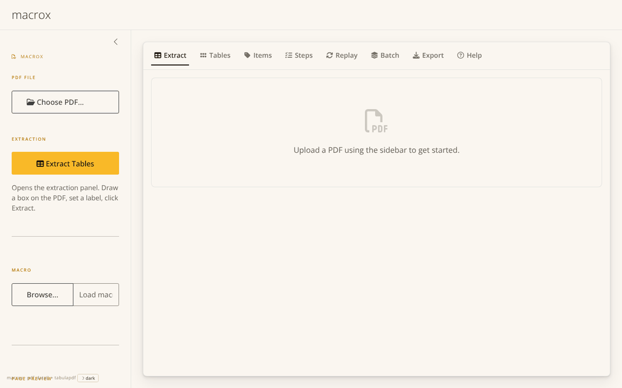

The sidebar on the left stays visible on every tab:

- **PDF File** opens a file browser. Once a PDF is loaded, its name and page count appear underneath.
- **Extract Tables** jumps to the Extract tab.
- **Macro** loads a saved macro (`.yml`) into the current session.
- **Page Preview** is a thumbnail of the current page, with **Browse all pages** for scrolling through the whole document. The page browser loads PDF.js from a CDN, so it needs an internet connection.

## Extract a table

Choose a PDF and open the **Extract** tab. The page you are looking at is on the left and the extraction controls are on the right.

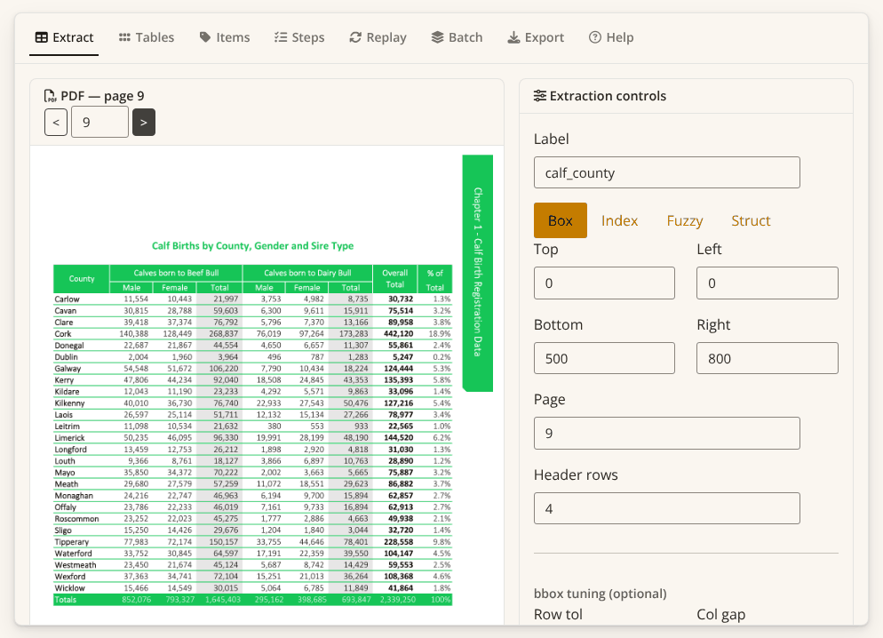

1. Step through the PDF with the `<` and `>` buttons (or the left and right arrow keys) until you reach the page with your table.
2. Give the table a **label**. This is the name it will have in the Tables tab, in exports and in the macro.
3. Set the **page** and the number of **header rows**. Tables with a two-level header need `2` or more, and macrox joins the header cells into single column names.
4. Optionally, **draw a box** around the table on the page image and click **Use selection**. This fills in the Top, Left, Bottom and Right fields. Without a box, the whole page is scanned.
5. Pick a **method** and click **Extract**.

The four tabs above the form are different ways of telling macrox *where* the table is:

| Tab | Use it when |
| --- | --- |
| **Box** | You know the page and can draw (or type) the area. The most reliable option. |
| **Index** | You know the page and that it is, say, the second table on it. |
| **Fuzzy** | The page number changes between reports, but the table’s caption stays similar. |
| **Struct** | You want records (several fields, one row per entity found) rather than a grid. Needs GLiNER2, set up with `setup_gliner()`. |

The **method** controls *how* the table is read:

| Method | Best for |
| --- | --- |
| `bbox` | A word-position engine. Good when a page has charts, missing grid lines, or numbers that run together. Pair it with a drawn area. |
| `lattice` | Clean tables with visible grid lines (needs Java, through tabulapdf). |
| `stream` | Tables aligned with spaces rather than lines (tabulapdf). |
| `llm` | Complex or scanned layouts, using an LLM that reads an image of the page. Needs an API key. |
| `docling` | An offline ML layout model for scanned or complex pages. Run `setup_docling()` once first. |

For this page, `bbox` with four header rows works well. A notification confirms what was read, and a preview appears under the **Extract** button.

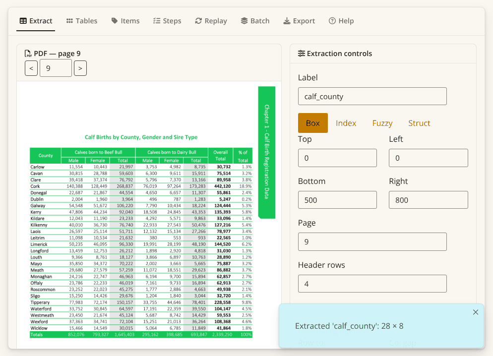

## Clean it up

Each extracted table gets its own sub-tab in the **Tables** tab, with its size (here 28 rows by 8 columns) and a row of buttons underneath.

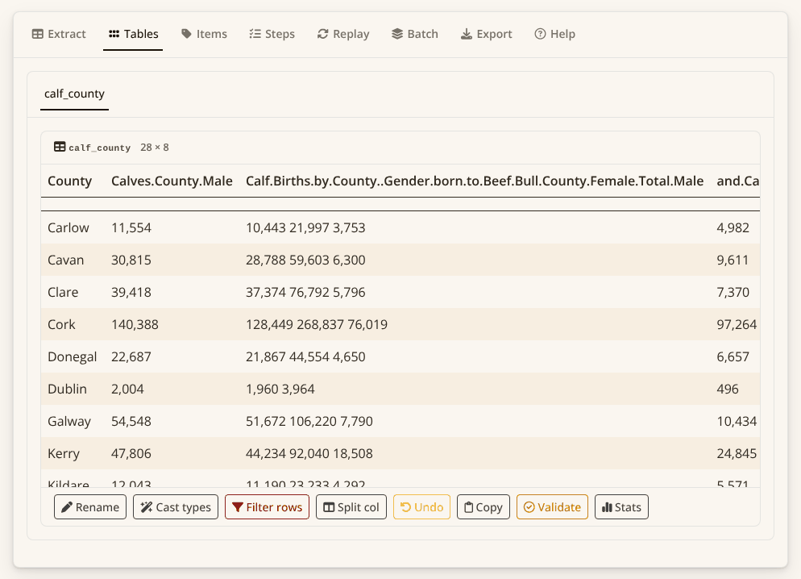

| Button | What it does |
| --- | --- |
| **Rename** | Rename columns. |
| **Cast types** | Convert columns to numeric, integer, date and so on. |
| **Filter rows** | Drop rows by a condition, for example the `Totals` row. |
| **Split col** | Split one column into several (see below). |
| **Undo** | Step back through the last few changes to this table. |
| **Copy** | Copy the table to the clipboard as tab-separated text. |
| **Validate** | Check the table against rules you write, one per line, as `rule_name: expression`. |
| **Stats** | Summarise each column: type, range or number of unique values, and missing values. |

### Split merged cells

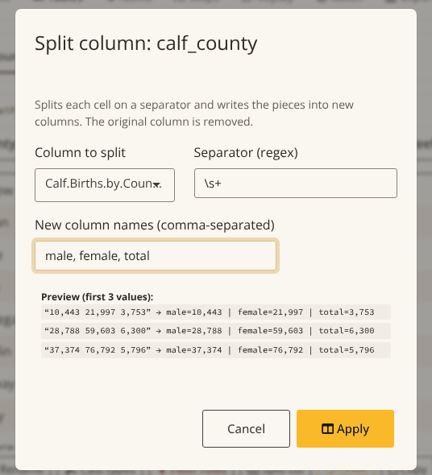

Pick the column, give a separator (a regular expression, `\s+` meaning “any whitespace” by default) and the names of the new columns. The dialog previews the first three values before you commit. Click **Apply** and the single column is replaced by three.

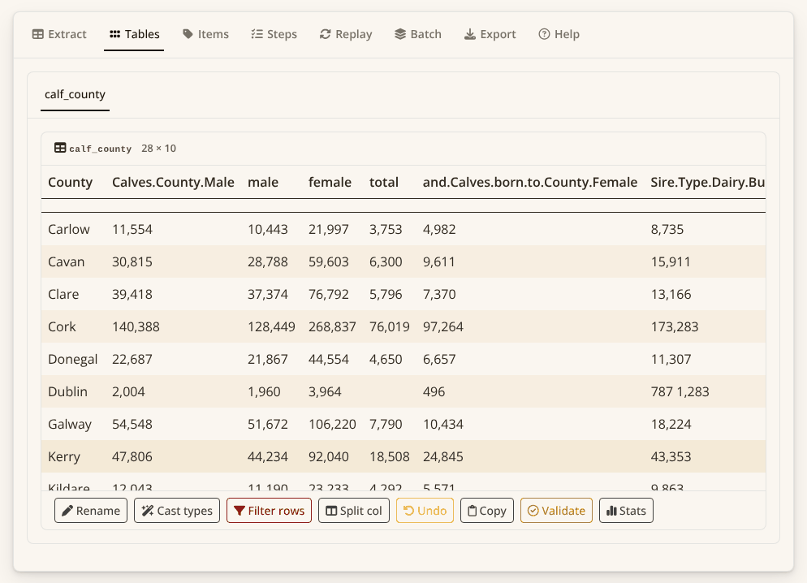

The same step in a script is `split_column()`:

```r
sess <- mx_session("AIM_Stats_Report_060525.pdf")
sess |> select_table("calf_county", page = 9, method = "bbox", header_rows = 4)
sess |> split_column("calf_county",
                     col  = "Calf.Births.by.County..Gender.born.to.Beef.Bull.County.Female.Total.Male",
                     into = c("male", "female", "total"))
```

## Review the recorded steps

Every extraction and every cleaning action is recorded on the **Steps** tab. Click a step to see its exact parameters, and remove a step by number if it was a mistake.

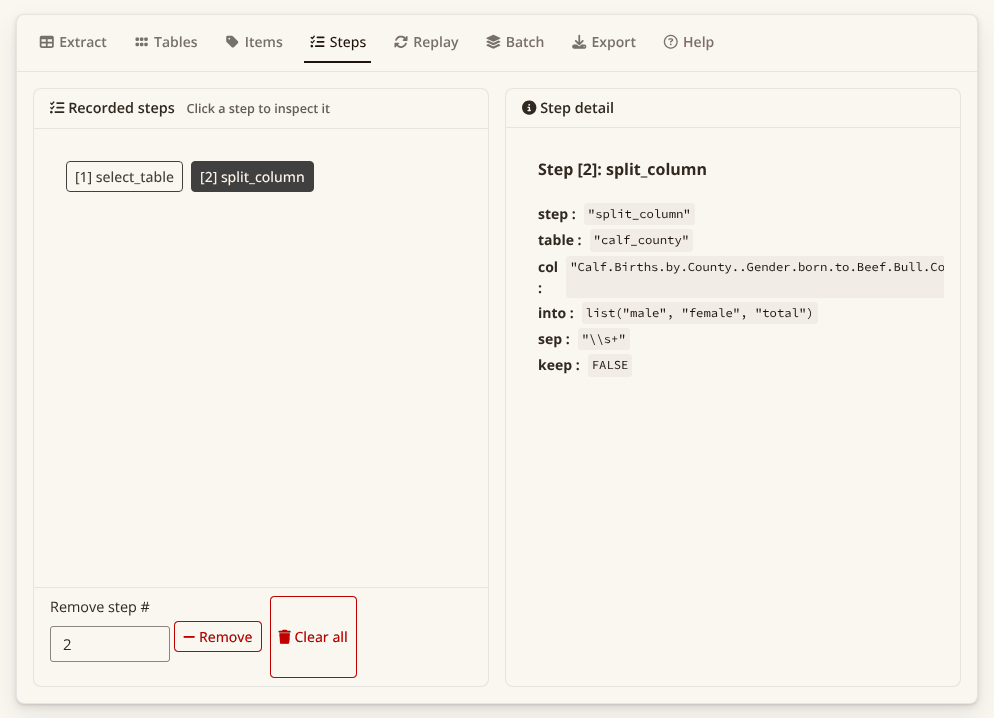

This list is the macro. Nothing else needs to be saved for it to be replayable.

## Export

The **Export** tab has two halves.

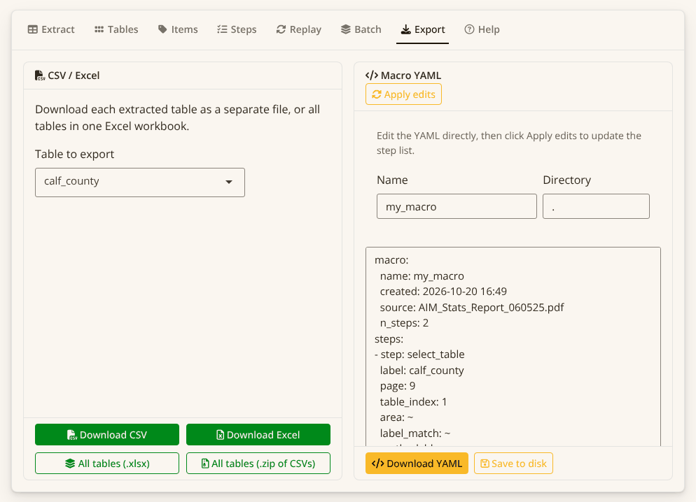

- **CSV / Excel** (left) downloads the selected table, or all tables at once as one workbook or a zip of CSVs.
- **Macro YAML** (right) shows the recorded steps as YAML. You can edit the text directly and click **Apply edits** to update the step list, then **Download YAML** or **Save to disk**.

The macro for this walkthrough starts like this (abridged):

```yaml
macro:
  name: my_macro
  source: AIM_Stats_Report_060525.pdf
  n_steps: 2
steps:
- step: select_table
  label: calf_county
  page: 9
  table_index: 1
  ...
```

## Reuse the macro

Next year’s report will have the same layout and a different PDF. There are three ways to run the macro against it.

- **Replay** runs one macro against one PDF. The tables appear in the Tables tab, ready to clean further or export.
- **Batch** runs one macro across several PDFs and lets you download all the results as an Excel workbook or a zip of CSVs.
- **Replay** also has a **Diff** panel, which runs the macro on two PDFs and compares them: row counts, added or removed tables, and cell-level changes.

Outside the app, the same macro replays from R:

```r
tables <- mx_replay("AIM_Stats_Report_2025.pdf", macro = "my_macro")
```

See `vignette("macros-and-testing")` for parameterised macros, batch replay and snapshot testing in CI.

## Other tabs

- **Items** extracts single values, such as an invoice number or a report date, using an LLM or the local GLiNER2 model. See `vignette("llm-integration")` for provider setup.
- **Help** is a one-page summary of the workflow and the extraction methods, inside the app.

To go further, `vignette("extraction-methods")` covers `bbox` tuning, multi-page tables and choosing a method.